# Assignment 2

## Exercise a)

Before you start to build the model, you need to derive the energy consumption from the given parameters and preprocess the data. The energy use [kWh] per shower can be estimated using the following formula (neglecting units); we assume a cold water temperature of 12 degrees and an average water heating efficiency of 65%.

```r
# create new variable ???energy??? and import it into shower_data
shower_data <- mutate(shower_data, energy = Volume * (Avgtemperature - 12/0.65) * (4.184 / 3600))
```

## Exercise b)

Remove showers with a negative energy consumption. Moreover, identify and remove outliers on the dependent variable, if they exist. Justify your choice.

```r
# delete all energy-consumptions which are smaller or equal zero
shower_data <- filter(shower_data, energy >= 0)

# detect outliers with specifying the Interquartile Range of the dataset (first quartile is at 10% and thrid quartile starts at 90%)
# remove outliers from shower_data (<-NA)
qnt <- quantile(shower_data$energy, probs=c(.10, .90), na.rm = T)
H <- 1.5 * IQR(shower_data$energy, na.rm = T)
shower_data$energy[shower_data$energy < (qnt[1] - H)] <- NA
shower_data$energy[shower_data$energy > (qnt[2] + H)] <- NA
```

## Exercise c)

Estimate the energy savings using a difference-in-difference (DiD) model; do not include items from the questionnaire. Then, interpret the estimated values of the DiD model. Do the values reflect what one would expect from a successful randomization?

```r
# define baseline-phase
baseline <- shower_data %>% filter(Shower < 10)
# define intervention-phase
intervention <- shower_data %>% filter(Shower >= 10)

# define treatment- and control-group for baselinephase
baseline_treatment <- baseline %>% filter(group > 2)
baseline_control <- baseline %>% filter(group <= 2)

# define treatment- and control-group for interventionphase
intervention_treatment <- intervention %>% filter(group > 2)
intervention_control <- intervention %>% filter(group <= 2)

avg_intervention_treatment <- intervention_treatment %>% summarise(avgEnergy = mean(energy))
avg_intervention_control <- intervention_control %>% summarise(avgEnergy = mean(energy))
avg_baseline_treatment <- baseline_treatment %>% summarise(avgEnergy = mean(energy))
avg_baseline_control <- baseline_control %>% summarise(avgEnergy = mean(energy))

# Add dummy variable for intervention phase
shower_data <- shower_data %>% mutate(intervention = ifelse(Shower < 10, 0, ifelse(Shower >= 10, 1, NA)))

# Add dummy variable for treatment group
shower_data <- shower_data %>% mutate(treatment = ifelse(group <= 2, 0, ifelse(group > 2, 1, NA)))

# create DiD model
model <- lm(energy ~ Volume + treatment + intervention + treatment * intervention, data = shower_data)
```

## Exercise d)

Now extend the basic model by including the following variables as interacting variables of your DiD model. Please add each of the following variables separately to the basic model (i. e., first step: DiD with Baseline, second step: DiD with Age, .). - Baseline Consumption - Age - Long hair (0=no) - Environmental attitude (att5: “ich verhalte mich auch dann umweltbewusst, wenn es erheblich h?here Kosten und M?hen verursacht”; 5 = strong agreement) Which variables have a statistically significant influence on the saving effects?

```r
# joined shower_data with survey_data to create new DiD models
joined_data <- inner_join(shower_data, survey_data, by = "Hh_ID")

# create new variable basline_consumption
sumVolume <- joined_data %>% filter(intervention == 0) %>% group_by(Hh_ID) %>% summarize(baseline_consumption = sum(Volume))
joined_data <- inner_join(joined_data, sumVolume, by = "Hh_ID")

# create new DiD model with new variable baseline_consumption
model1 <- lm(energy ~ Volume + baseline_consumption + treatment + intervention + treatment * intervention, data = joined_data)
# Akaike Information Criterion gives a value of how good the model fits (lowest value is best fitted model)
# -21495.9
AIC(model1)
```

```
## [1] -21495.9
```

```r
#create DiD model with variable alter
model2 <- lm(energy ~ Volume + alter + treatment + intervention + treatment * intervention, data = joined_data)
# -22161.48
AIC(model2)
```

```
## [1] -22161.48
```

```r
# create dummy variable to tell if the participants has long hair
joined_data <- joined_data %>% mutate(long_hair = ifelse(X03d_longhair >= 1, "Yes", ifelse(X03d_longhair == 0, "No", NA)))
# create DiD model with variable long_hair
model3 <- lm(energy ~ Volume + long_hair + treatment + intervention + treatment * intervention, data = joined_data)
# -21666.59
AIC(model3)
```

```
## [1] -21666.59
```

```r
#create DiD with variable att5
model4 <- lm(energy ~ Volume + att5 + treatment + intervention + treatment * intervention, data = joined_data)
# -21562.88
AIC(model4)
```

```
## [1] -21562.88
```

```r
# The model which fits best is the one with the variable ???alter??? (model2) because it has the lower AIC-value
```

## Exercise e)

Include all the variables from task d) in one single DiD model. Visualize the coefficients in a bar plot that also contains the 90% confidence intervals for each coefficient.

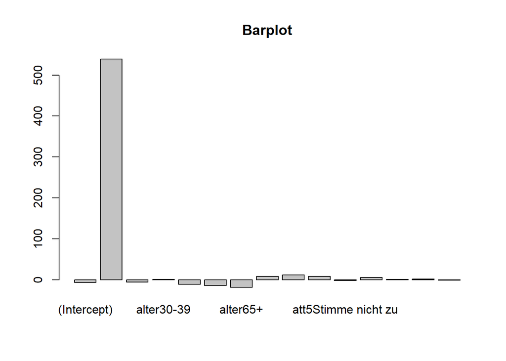

```r
# applying all variables from Exercise d) to a DiD model
model5 <- lm(energy ~ Volume + baseline_consumption + alter + long_hair + att5 + treatment + intervention + treatment * intervention, data = joined_data)

barplot(t(summary(model5)$coefficients), main = "Barplot")
```

## Exercise f)

Assume you want to maximize the saving effects of an energy conservation campaign. If you can ask two questions (e.g. using a survey) before starting the campaign, which questions would you ask to determine to whom to give a device? How high would the energy saving effect be if you give devices to 50% of the participants? Hint: You may create a DiD only with the participants having favorable characteristics, to compare the energy savings easily with the complete sample of the present study/data set.

```r
# To find out which questions are appropriate we checked the already existing answers to question #5 and found out, that participants of the treatment group which answered the question with ???Stimme nicht zu??? have a higher water saving so  we pick question #5 as one of our questions to add to the survey before starting the campaign
test <- joined_data %>% filter(att5 == "Stimme nicht zu")
model6 <- lm(energy ~ Volume + treatment + intervention + treatment * intervention, data = test)

test2 <- joined_data %>% filter(att5 == "Stimme zu")
model7 <- lm(energy ~ Volume + treatment + intervention + treatment * intervention, data = test2)

# For the second question we calculated the average showertime, splitted the outcome in two groups, clean_people which need more time to shower and dirty_people which aren't using that much time to shower.
# Comparing these two groups showed, that people of the treatment-group with a high showertime (clean_people) have a higher saving of energy than people who are used to shorter showertimes
# Hence, the second question would be: How much time do you spend in the shower while water with an average temperature is running?
test3 <- joined_data %>% group_by(Hh_ID) %>% summarize(avg_showertime = mean(Showertime))
test4 <- inner_join(joined_data, test3)
test5 <- test4 %>% mutate(clean_people = ifelse(avg_showertime >= mean(test3$avg_showertime), 1, ifelse(avg_showertime < mean(test3$avg_showertime), 0, NA)))
test6 <- test5 %>% filter(clean_people == 1)
test7 <- test5 %>% filter(clean_people == 0)

# comparing DiD models of clean_people and dirty_people
model8 <- lm(energy ~ Volume + avg_showertime + treatment + intervention + treatment * intervention, data = test6)
model9 <- lm(energy ~ Volume + avg_showertime + treatment + intervention + treatment * intervention, data = test7)

# By cutting the participants down to 50% under the condition, that the randomization is reliable, the energy saving would be the same as before, noting that an individual has more impact on the outcome then before.
```